# Webscrapping Assignment

Tanvi Arora

July 8, 2018

```r
knitr::opts_chunk$set(echo = TRUE)

# load libraries
library(knitr)
library(XML)
library(RCurl)
library(stringr)
```

```r
library(ggplot2)
# source functions file
source('Code/webextr_functions.R')

# read knitr chunks
read_chunk('Code/HarryPotter.R')
read_chunk('Code/webextr_functions.R')
read_chunk('Code/SportsBall.R')
```

## Harry Potter cast

IMDB has listings of full cast members for movies. Get Cast listings for movie - “Harry Potter and the Deathly Hallows: Part 2” Given URL - [Castings for Harry Potter and the Deathly Hallows: Part 2](http://www.imdb.com/title/tt1201607/fullcredits?ref_=tt_ql_1.)

#### Data fetch from website

```r
# get URL for website
HP.file <- "https://www.imdb.com/title/tt1201607/fullcredits?ref_=tt_ql_1"
#HP.doc<- xmlTreeParse(HP.fileurl, useInternal = TRUE)
HP.fileurl <- getURL(HP.file)

# Read HTML tables
HP.table.df <- readHTMLTable(HP.fileurl,as.data.frame=T)
```

#### Tidying of web data

Dataframe fetched has all the tables from the web page. Cast listings table is the 3rd table. We want to fetch 3rd table and then create a dataframe with only the columns of Actor and Character Names. As part of cleanup of data below steps are taken -  
- remove and rows with null/NA data  
- give meaningful column names to the dataframe  
- remove carriage returns or newline from the data  
- replace multiple whitespaces with single whitespace to make it look better.

```r
#fetch required table
#######################
# List of Casts seems to be the 3rd table

str(HP.table.df[[3]])
```

```
## 'data.frame':    150 obs. of  4 variables:
##  $ V1: Factor w/ 2 levels "","Rest of cast listed alphabetically:": 1 1 1 1 1 1 1 1 1 1 ...
##  $ V2: Factor w/ 149 levels "Aaron Virdee",..: 118 106 4 29 125 45 46 40 27 147 ...
##  $ V3: Factor w/ 1 level "...": 1 1 1 1 1 1 1 1 1 1 ...
##  $ V4: Factor w/ 115 levels "Aberforth Dumbledore",..: 57 76 81 39 88 41 59 15 29 37 ...
```

```r
#extract cast and role

HP.casts <- HP.table.df[[3]][,c(2,4)]
names(HP.casts) <- c("Actor","Character")
#HP.casts <- as.character(HP.casts)
str(HP.casts)
```

```
## 'data.frame':    150 obs. of  2 variables:
##  $ Actor    : Factor w/ 149 levels "Aaron Virdee",..: 118 106 4 29 125 45 46 40 27 147 ...
##  $ Character: Factor w/ 115 levels "Aberforth Dumbledore",..: 57 76 81 39 88 41 59 15 29 37 ...
```

```r
#HP.casts

# tidy table data
####################
# remove rows with NA
HP.casts <- HP.casts[!is.na(HP.casts$Actor),]

# remove carraigereturns or newlines
HP.casts$Character <- str_replace_all(HP.casts$Character, "[\r\n]", "")

#HP.casts

# replace multiple whitespaces with single whitespace

HP.casts$Character <- str_squish(HP.casts$Character)

HP.casts
```

```
##                             Actor
## 1                   Ralph Fiennes
## 2                  Michael Gambon
## 3                    Alan Rickman
## 4                Daniel Radcliffe
## 5                    Rupert Grint
## 6                     Emma Watson
## 7                    Evanna Lynch
## 8                Domhnall Gleeson
## 9                  Clémence Poésy
## 10                  Warwick Davis
## 11                      John Hurt
## 12           Helena Bonham Carter
## 13                    Graham Duff
## 14                Anthony Allgood
```

[output cut: 285 more lines]

#### Display Data

Now that we have required data, we want to split Actor Name as FirstName and Surname.

```r
# Data Presentation

#Split Name into First Name , LastName
HP.casts$FirstName <- lapply(HP.casts$Actor, function(x) head(strsplit(as.character(x),split = " ")[[1]],-1))
HP.casts$Surname <- lapply(HP.casts$Actor, function(x) tail(strsplit(as.character(x),split = " ")[[1]],1))
#HP.casts$LastName <- strsplit(HP.casts$Actor, " ")[[-1]]

HP.casts.display <- subset(HP.casts,select =c("FirstName","Surname","Character"))

# Present the first 10 rows of the cast list
head(HP.casts.display,10)
```

```
##    FirstName   Surname                            Character
## 1      Ralph   Fiennes                       Lord Voldemort
## 2    Michael    Gambon           Professor Albus Dumbledore
## 3       Alan   Rickman              Professor Severus Snape
## 4     Daniel Radcliffe                         Harry Potter
## 5     Rupert     Grint                          Ron Weasley
## 6       Emma    Watson                     Hermione Granger
## 7     Evanna     Lynch                        Luna Lovegood
## 8   Domhnall   Gleeson                         Bill Weasley
## 9   Clémence     Poésy                       Fleur Delacour
## 10   Warwick     Davis Griphook / Professor Filius Flitwick
```

## SportsBall

On the ESPN website, there are statistics of each NBA player. Use data for [San Antonio Spurs](http://www.espn.com/nba/team/stats/_/name/sa/san-antonio-spurs) and fetch data from the **Shooting Statistics** table.

#### Data fetch from website

```r
# get URL for website
sb.table.df <- get_web_table("http://www.espn.com/nba/team/stats/_/name/sa/san-antonio-spurs",2)

str(sb.table.df)
```

```
## 'data.frame':    16 obs. of  15 variables:
##  $ V1 : Factor w/ 16 levels "Brandon Paul, SG",..: 13 9 11 14 10 5 15 12 8 2 ...
##  $ V2 : Factor w/ 14 levels "0.0","0.6","1.0",..: 14 13 11 12 9 8 8 6 7 4 ...
##  $ V3 : Factor w/ 14 levels "0.0","1.0","11.4",..: 14 5 3 4 12 11 12 8 8 9 ...
##  $ V4 : Factor w/ 15 levels ".000",".167",..: 15 11 9 6 7 10 5 12 13 4 ...
##  $ V5 : Factor w/ 11 levels "0.0","0.2","0.3",..: 10 5 9 6 8 6 1 2 1 4 ...
##  $ V6 : Factor w/ 13 levels "0.0","0.6","0.7",..: 11 5 13 10 10 6 5 2 4 7 ...
##  $ V7 : Factor w/ 11 levels ".000",".188",..: 11 9 7 3 6 10 1 6 1 3 ...
##  $ V8 : Factor w/ 11 levels "0.0","0.6","0.8",..: 11 10 3 4 8 6 4 8 2 5 ...
##  $ V9 : Factor w/ 10 levels "0.0","0.8","1.0",..: 10 9 3 5 7 5 4 6 2 5 ...
##  $ V10: Factor w/ 12 levels ".835","0.00",..: 12 11 8 3 9 7 4 10 6 4 ...
##  $ V11: Factor w/ 13 levels "0.0","0.6","0.7",..: 11 13 8 12 6 7 9 6 8 4 ...
##  $ V12: Factor w/ 15 levels "0.0","0.4","1.0",..: 7 5 11 15 10 12 14 9 8 6 ...
##  $ V13: Factor w/ 15 levels ".000",".300",..: 15 6 12 7 9 4 5 11 13 3 ...
##  $ V14: Factor w/ 16 levels ".000",".700",..: 16 13 9 4 10 11 3 14 12 6 ...
##  $ V15: Factor w/ 15 levels "0.00","0.25",..: 15 7 11 5 8 9 4 10 13 3 ...
```

#### Tidying of web data

Data received has a header record and Totals record. These are not part of the observation and will be removed from the dataset. Header record will be used as column names after renaming some of the columns by sustituting ‘%’ with ’_per’. Player column has Player name and his position, these will be seperated into two different columns : Playername and Playerposition. Data fetched from the website is factor , so we will convert names data to character and all the statistics will be converted to numeric so we can use them for visualization.

```r
# convert factor data to character
sb.table.df.c <- rapply(sb.table.df, as.character , classes="factor", how="replace")
str(sb.table.df.c)
```

```
## 'data.frame':    16 obs. of  15 variables:
##  $ V1 : chr  "PLAYER" "LaMarcus Aldridge, PF" "Patty Mills, PG" "Rudy Gay, SF" ...
##  $ V2 : chr  "FGM" "7.4" "5.0" "5.2" ...
##  $ V3 : chr  "FGA" "16.0" "11.4" "13.0" ...
##  $ V4 : chr  "FG%" ".463" ".439" ".400" ...
##  $ V5 : chr  "3PM" "0.6" "2.6" "0.8" ...
##  $ V6 : chr  "3PA" "1.0" "7.0" "3.6" ...
##  $ V7 : chr  "3P%" ".600" ".371" ".222" ...
##  $ V8 : chr  "FTM" "8.2" "0.8" "1.0" ...
##  $ V9 : chr  "FTA" "8.4" "1.0" "1.8" ...
##  $ V10: chr  "FT%" "0.98" "0.80" "0.56" ...
##  $ V11: chr  "2PM" "6.8" "2.4" "4.4" ...
##  $ V12: chr  "2PA" "15.0" "4.4" "9.4" ...
##  $ V13: chr  "2P%" ".453" ".545" ".468" ...
##  $ V14: chr  "PPS" "1.475" "1.175" ".938" ...
##  $ V15: chr  "AFG%" "0.48" "0.55" "0.43" ...
```

```r
# define column names
# first record is the header. Assign it to column names and remove it from the observation
# substitute '%' in header name with _per
sb.table.df.c[1,] <- str_replace_all(sb.table.df.c[1,],"%","_per")
# assign names
names(sb.table.df.c) <- sb.table.df.c[1,]
str(sb.table.df.c)
```

```
## 'data.frame':    16 obs. of  15 variables:
##  $ PLAYER : chr  "PLAYER" "LaMarcus Aldridge, PF" "Patty Mills, PG" "Rudy Gay, SF" ...
##  $ FGM    : chr  "FGM" "7.4" "5.0" "5.2" ...
##  $ FGA    : chr  "FGA" "16.0" "11.4" "13.0" ...
##  $ FG_per : chr  "FG_per" ".463" ".439" ".400" ...
##  $ 3PM    : chr  "3PM" "0.6" "2.6" "0.8" ...
##  $ 3PA    : chr  "3PA" "1.0" "7.0" "3.6" ...
##  $ 3P_per : chr  "3P_per" ".600" ".371" ".222" ...
##  $ FTM    : chr  "FTM" "8.2" "0.8" "1.0" ...
##  $ FTA    : chr  "FTA" "8.4" "1.0" "1.8" ...
##  $ FT_per : chr  "FT_per" "0.98" "0.80" "0.56" ...
##  $ 2PM    : chr  "2PM" "6.8" "2.4" "4.4" ...
##  $ 2PA    : chr  "2PA" "15.0" "4.4" "9.4" ...
##  $ 2P_per : chr  "2P_per" ".453" ".545" ".468" ...
##  $ PPS    : chr  "PPS" "1.475" "1.175" ".938" ...
##  $ AFG_per: chr  "AFG_per" "0.48" "0.55" "0.43" ...
```

```r
#first record is the header record, which is not an observation, remove it from dataframe
sb.table.df.c <- tail(sb.table.df.c,-1)
head(sb.table.df.c)
```

```
##                  PLAYER FGM  FGA FG_per 3PM 3PA 3P_per FTM FTA FT_per 2PM
## 2 LaMarcus Aldridge, PF 7.4 16.0   .463 0.6 1.0   .600 8.2 8.4   0.98 6.8
## 3       Patty Mills, PG 5.0 11.4   .439 2.6 7.0   .371 0.8 1.0   0.80 2.4
## 4          Rudy Gay, SF 5.2 13.0   .400 0.8 3.6   .222 1.0 1.8   0.56 4.4
## 5     Manu Ginobili, SG 3.0  7.4   .405 1.2 3.6   .333 1.8 2.2   0.82 1.8
## 6   Dejounte Murray, PG 2.8  6.2   .452 0.8 1.2   .667 1.4 1.8   0.78 2.0
## 7       Tony Parker, PG 2.8  7.4   .378 0.0 1.0   .000 1.0 1.4   0.71 2.8
##    2PA 2P_per   PPS AFG_per
## 2 15.0   .453 1.475    0.48
## 3  4.4   .545 1.175    0.55
## 4  9.4   .468  .938    0.43
## 5  3.8   .474 1.216    0.49
## 6  5.0   .400 1.258    0.52
## 7  6.4   .438  .892    0.38
```

```r
# last record is the Totals row, which is not an observation. Remove it from the dataframe

sb.table.df.c <- head(sb.table.df.c,-1)
tail(sb.table.df.c)
```

```
##                  PLAYER FGM FGA FG_per 3PM 3PA 3P_per FTM FTA FT_per 2PM
## 10      Bryn Forbes, SG 1.3 4.3   .294 0.5 2.3   .222 1.3 1.8   0.71 0.8
## 11      Danny Green, SG 1.6 6.0   .267 1.0 4.0   .250 0.0 0.0   0.00 0.6
## 12     Davis Bertans, C 0.6 3.6   .167 0.6 3.2   .188 1.6 2.2   0.73 0.0
## 13    Derrick White, PG 1.0 2.0   .500 0.3 0.7   .500 0.0 0.0   0.00 0.7
## 14 Joffrey Lauvergne, C 1.0 1.0  1.000 0.0 0.0   .000 0.0 0.0   0.00 1.0
## 15     Brandon Paul, SG 0.0 0.0   .000 0.0 0.0   .000 0.0 0.0   0.00 0.0
##    2PA 2P_per   PPS AFG_per
## 10 2.0   .375 1.000    0.35
## 11 2.0   .300  .700    0.35
## 12 0.4   .000  .944    0.25
## 13 1.3   .500 1.167    0.58
## 14 1.0  1.000 2.000    1.00
## 15 0.0   .000  .000    0.00
```

```r
# convert character to numeric
sb.table.df.c[,2:15] <- lapply(sb.table.df.c[,2:15], function(x) as.numeric(as.character(x)))
str(sb.table.df.c)
```

```
## 'data.frame':    14 obs. of  15 variables:
##  $ PLAYER : chr  "LaMarcus Aldridge, PF" "Patty Mills, PG" "Rudy Gay, SF" "Manu Ginobili, SG" ...
##  $ FGM    : num  7.4 5 5.2 3 2.8 2.8 2 2.4 1.3 1.6 ...
##  $ FGA    : num  16 11.4 13 7.4 6.2 7.4 4 4 4.3 6 ...
##  $ FG_per : num  0.463 0.439 0.4 0.405 0.452 0.378 0.5 0.6 0.294 0.267 ...
##  $ 3PM    : num  0.6 2.6 0.8 1.2 0.8 0 0.2 0 0.5 1 ...
##  $ 3PA    : num  1 7 3.6 3.6 1.2 1 0.6 0.8 2.3 4 ...
##  $ 3P_per : num  0.6 0.371 0.222 0.333 0.667 0 0.333 0 0.222 0.25 ...
##  $ FTM    : num  8.2 0.8 1 1.8 1.4 1 1.8 0.6 1.3 0 ...
##  $ FTA    : num  8.4 1 1.8 2.2 1.8 1.4 2 0.8 1.8 0 ...
##  $ FT_per : num  0.98 0.8 0.56 0.82 0.78 0.71 0.9 0.75 0.71 0 ...
##  $ 2PM    : num  6.8 2.4 4.4 1.8 2 2.8 1.8 2.4 0.8 0.6 ...
##  $ 2PA    : num  15 4.4 9.4 3.8 5 6.4 3.4 3.2 2 2 ...
##  $ 2P_per : num  0.453 0.545 0.468 0.474 0.4 0.438 0.529 0.75 0.375 0.3 ...
##  $ PPS    : num  1.475 1.175 0.938 1.216 1.258 ...
##  $ AFG_per: num  0.48 0.55 0.43 0.49 0.52 0.38 0.53 0.6 0.35 0.35 ...
```

```r
# split PLAYER into Player_name, Player_position

sb.table.df.c$Playername <- sapply(sb.table.df.c$PLAYER , function(x)  head(strsplit(x,split = ",")[[1]] ,1))
sb.table.df.c$Playerposition <- sapply(sb.table.df.c$PLAYER , function(x) tail(strsplit(x,split = ",")[[1]] ,1))

# display dataframe
sb.table.df.c
```

```
##                   PLAYER FGM  FGA FG_per 3PM 3PA 3P_per FTM FTA FT_per 2PM
## 2  LaMarcus Aldridge, PF 7.4 16.0  0.463 0.6 1.0  0.600 8.2 8.4   0.98 6.8
## 3        Patty Mills, PG 5.0 11.4  0.439 2.6 7.0  0.371 0.8 1.0   0.80 2.4
## 4           Rudy Gay, SF 5.2 13.0  0.400 0.8 3.6  0.222 1.0 1.8   0.56 4.4
## 5      Manu Ginobili, SG 3.0  7.4  0.405 1.2 3.6  0.333 1.8 2.2   0.82 1.8
## 6    Dejounte Murray, PG 2.8  6.2  0.452 0.8 1.2  0.667 1.4 1.8   0.78 2.0
## 7        Tony Parker, PG 2.8  7.4  0.378 0.0 1.0  0.000 1.0 1.4   0.71 2.8
## 8           Pau Gasol, C 2.0  4.0  0.500 0.2 0.6  0.333 1.8 2.0   0.90 1.8
## 9      Kyle Anderson, SF 2.4  4.0  0.600 0.0 0.8  0.000 0.6 0.8   0.75 2.4
## 10       Bryn Forbes, SG 1.3  4.3  0.294 0.5 2.3  0.222 1.3 1.8   0.71 0.8
## 11       Danny Green, SG 1.6  6.0  0.267 1.0 4.0  0.250 0.0 0.0   0.00 0.6
## 12      Davis Bertans, C 0.6  3.6  0.167 0.6 3.2  0.188 1.6 2.2   0.73 0.0
## 13     Derrick White, PG 1.0  2.0  0.500 0.3 0.7  0.500 0.0 0.0   0.00 0.7
## 14  Joffrey Lauvergne, C 1.0  1.0  1.000 0.0 0.0  0.000 0.0 0.0   0.00 1.0
## 15      Brandon Paul, SG 0.0  0.0  0.000 0.0 0.0  0.000 0.0 0.0   0.00 0.0
##     2PA 2P_per   PPS AFG_per        Playername Playerposition
## 2  15.0  0.453 1.475    0.48 LaMarcus Aldridge             PF
## 3   4.4  0.545 1.175    0.55       Patty Mills             PG
## 4   9.4  0.468 0.938    0.43          Rudy Gay             SF
## 5   3.8  0.474 1.216    0.49     Manu Ginobili             SG
## 6   5.0  0.400 1.258    0.52   Dejounte Murray             PG
## 7   6.4  0.438 0.892    0.38       Tony Parker             PG
## 8   3.4  0.529 1.500    0.53         Pau Gasol              C
## 9   3.2  0.750 1.350    0.60     Kyle Anderson             SF
## 10  2.0  0.375 1.000    0.35       Bryn Forbes             SG
## 11  2.0  0.300 0.700    0.35       Danny Green             SG
## 12  0.4  0.000 0.944    0.25     Davis Bertans              C
## 13  1.3  0.500 1.167    0.58     Derrick White             PG
## 14  1.0  1.000 2.000    1.00 Joffrey Lauvergne              C
## 15  0.0  0.000 0.000    0.00      Brandon Paul             SG
```

```r
str(sb.table.df.c)
```

```
## 'data.frame':    14 obs. of  17 variables:
##  $ PLAYER        : chr  "LaMarcus Aldridge, PF" "Patty Mills, PG" "Rudy Gay, SF" "Manu Ginobili, SG" ...
##  $ FGM           : num  7.4 5 5.2 3 2.8 2.8 2 2.4 1.3 1.6 ...
##  $ FGA           : num  16 11.4 13 7.4 6.2 7.4 4 4 4.3 6 ...
##  $ FG_per        : num  0.463 0.439 0.4 0.405 0.452 0.378 0.5 0.6 0.294 0.267 ...
##  $ 3PM           : num  0.6 2.6 0.8 1.2 0.8 0 0.2 0 0.5 1 ...
##  $ 3PA           : num  1 7 3.6 3.6 1.2 1 0.6 0.8 2.3 4 ...
##  $ 3P_per        : num  0.6 0.371 0.222 0.333 0.667 0 0.333 0 0.222 0.25 ...
##  $ FTM           : num  8.2 0.8 1 1.8 1.4 1 1.8 0.6 1.3 0 ...
##  $ FTA           : num  8.4 1 1.8 2.2 1.8 1.4 2 0.8 1.8 0 ...
##  $ FT_per        : num  0.98 0.8 0.56 0.82 0.78 0.71 0.9 0.75 0.71 0 ...
##  $ 2PM           : num  6.8 2.4 4.4 1.8 2 2.8 1.8 2.4 0.8 0.6 ...
##  $ 2PA           : num  15 4.4 9.4 3.8 5 6.4 3.4 3.2 2 2 ...
##  $ 2P_per        : num  0.453 0.545 0.468 0.474 0.4 0.438 0.529 0.75 0.375 0.3 ...
##  $ PPS           : num  1.475 1.175 0.938 1.216 1.258 ...
##  $ AFG_per       : num  0.48 0.55 0.43 0.49 0.52 0.38 0.53 0.6 0.35 0.35 ...
##  $ Playername    : chr  "LaMarcus Aldridge" "Patty Mills" "Rudy Gay" "Manu Ginobili" ...
##  $ Playerposition: chr  " PF" " PG" " SF" " SG" ...
```

#### Visualization

Plot a bar chart that shows *Field Goals Percentage Per Game* for each person.

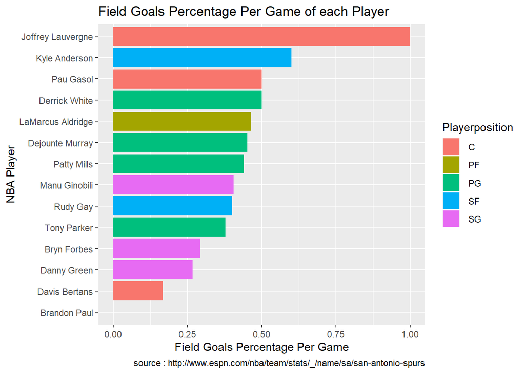

```r
ggplot(data=sb.table.df.c, aes(reorder(Playername,FG_per),FG_per)) + geom_bar(stat= "identity", aes(fill = Playerposition)) + coord_flip() + labs(title="Field Goals Percentage Per Game of each Player", caption="source : http://www.espn.com/nba/team/stats/_/name/sa/san-antonio-spurs") + xlab("NBA Player") + ylab("Field Goals Percentage Per Game")
```